# Food at College

```r
  # From your file menu (at the top of R-Studio) select:
  # "Session -> Set working directory -> To source file location"
  # Then play this chunk to get the data into R.
library(mosaic)
library(car)
library(DT)
library(pander)
library(readr)
food <- read_csv("food.csv") #food.csv is in the Data folder...
```

## 1. Context

This analysis investigates the relationship between how healthy individuals feel (measured by the healthy_feeling variable) and how often their parents cooked during their childhood (measured by parents_cook). Understanding this relationship could shed light on potential long-term influences of early home-cooked meals on health perceptions later in life.

## 2. Hypotheses: One-Way ANOVA

We set up a one-way ANOVA to test whether the mean perceived healthy feeling differs by parental cooking frequency.

\begin{aligned}H_0&: \mu_1 = \mu_2 = \dots = \mu_k\\H_A&: \text{At least one group mean is different.}\end{aligned}

## 3. Numerical and Graphical Summaries

```r
  # Load data
  df <- read.csv("food.csv")

  df <- df %>%
    mutate(healthy_feeling = case_when(
      healthy_feeling == 1 ~ 10,
      healthy_feeling == 2 ~ 9,
      healthy_feeling == 3 ~ 8,
      healthy_feeling == 4 ~ 7,
      healthy_feeling == 5 ~ 6,
      healthy_feeling == 6 ~ 5,
      healthy_feeling == 7 ~ 4,
      healthy_feeling == 8 ~ 3,
      healthy_feeling == 9 ~ 2,
      healthy_feeling == 10 ~ 1,
      TRUE ~ healthy_feeling  # catch any other values
    )) %>%
    filter(
      parents_cook < 4
    )

# Summarize healthy_feeling by parents_cook with reversed scoring
summary_table <- df %>%
  group_by(parents_cook) %>%
  summarise(Count = n(),
              Mean = round(mean(healthy_feeling, na.rm = TRUE), 2),
              SD = round(sd(healthy_feeling, na.rm = TRUE), 2))

pander(summary_table)
```

| parents_cook | Count | Mean | SD |
| --- | --- | --- | --- |
| 1 | 75 | 5.52 | 2.69 |
| 2 | 36 | 5.28 | 2.42 |
| 3 | 13 | 6.08 | 2.25 |

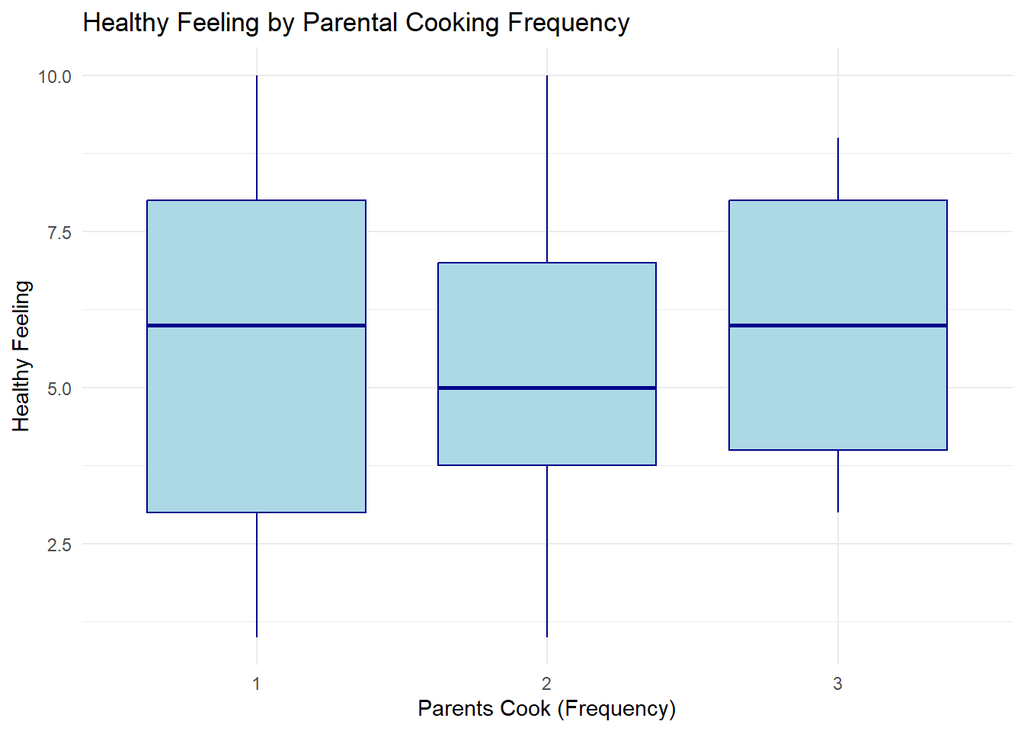

```r
# Create boxplot using ggplot2
p <- ggplot(df, aes(x = factor(parents_cook), y = healthy_feeling)) +
  geom_boxplot(fill = 'lightblue', color = 'darkblue') +
  labs(title = "Healthy Feeling by Parental Cooking Frequency",
        x = "Parents Cook (Frequency)",
        y = "Healthy Feeling") +
  theme_minimal()

print(p)
```

Based on the numerical and graphical summaries, it appears individuals whose parents cooked once or twice a week during their childhood feel healthier in adulthood.

## Anova Test

```r
# Perform one-way ANOVA

anova_mod <- aov(healthy_feeling ~ factor(parents_cook), data = df)
anova_summary <- summary(anova_mod)
pander(anova_summary)
```

Analysis of Variance Model

|  | Df | Sum Sq | Mean Sq | F value | Pr(>F) |
| --- | --- | --- | --- | --- | --- |
| **factor(parents_cook)** | 2 | 6.127 | 3.063 | 0.4617 | 0.6313 |
| **Residuals** | 121 | 802.9 | 6.635 | NA | NA |

The ANOVA test results tell us that even though we saw some differences in the average “healthy_feel” scores across the different parental cooking frequency groups, those differences are likely due to random chance. There’s no strong statistical evidence to say that how often your parents cooked when you were a kid has a significant impact on how healthy you feel now, based on this data.

## Residual Plot

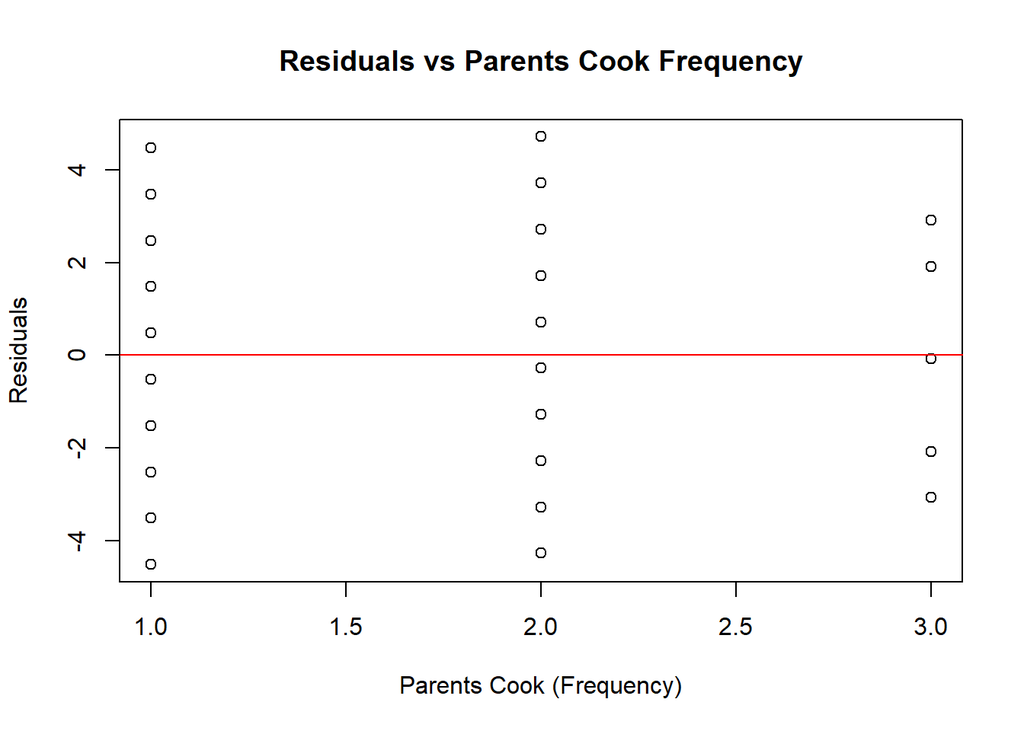

```r
# Residual plot for ANOVA model
model_resid <- residuals(anova_mod)
plot(df$parents_cook, model_resid,
      main = "Residuals vs Parents Cook Frequency",
      xlab = "Parents Cook (Frequency)",
      ylab = "Residuals")
abline(h = 0, col = "red")
```

## QQPlot

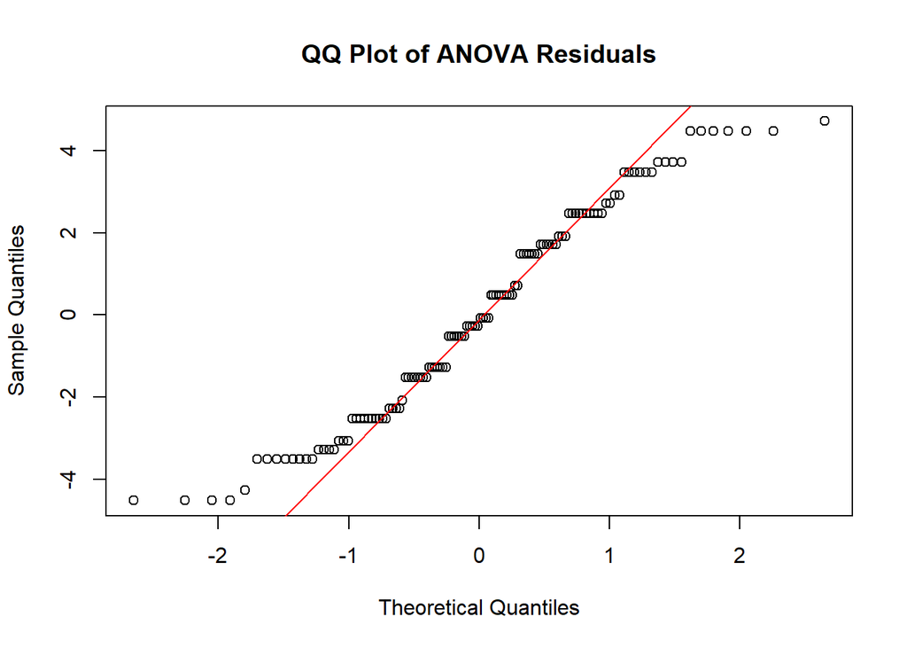

```r
qqnorm(model_resid, main = "QQ Plot of ANOVA Residuals")
qqline(model_resid, col = "red")
```

This QQ (Quantile-Quantile) plot of ANOVA residuals is used to assess the normality assumption of the residuals. Ideally, if the residuals are normally distributed, the points on the plot should fall closely along the red diagonal line. In this plot, while the central points generally follow the line, there are noticeable deviations at both ends. Specifically, the points at the lower and upper tails of the distribution deviate from the straight line, suggesting that the residuals might not be perfectly normally distributed. This indicates potential violations of the normality assumption, which could affect the reliability of the p-values from the ANOVA test. While moderate deviations might not invalidate the results entirely, significant deviations, as observed here, suggest that caution should be exercised when interpreting the ANOVA results.

## 6. Comparison with Non-Parametric Test

Based on the residual and QQ plots, since the requirements are not met, we perform a Kruskal-Wallis test as a non-parametric alternative.

## 7. Kruskal-Wallis Test

**Hypotheses**

**Null hypothesis (H₀)**: The distribution of healthy_feeling scores is the same across all parental cooking frequency groups.

**Alternative hypothesis (H₁)**: At least one group differs in the distribution of healthy_feeling scores.

Since the assumptions for ANOVA were not met (as seen in the residual and QQ plots), the Kruskal-Wallis test provides a more appropriate, non-parametric method for comparing multiple groups when normality and homogeneity of variances are questionable.

```r
kruskal_result <- kruskal.test(healthy_feeling ~ factor(parents_cook), data = df)
pander(kruskal_result)
```

Kruskal-Wallis rank sum test: `healthy_feeling` by `factor(parents_cook)`

| Test statistic | df | P value |
| --- | --- | --- |
| 0.9285 | 2 | 0.6286 |

The Kruskal-Wallis test produced a test statistic of **0.9285** with **2 degrees of freedom**, resulting in a **p-value of 0.6286**. Since this p-value is greater than the significance level of 0.05, we **fail to reject the null hypothesis**. This means we do not have sufficient evidence to conclude that perceived healthiness differs based on how often parents cooked during the respondent’s childhood.

## 8. Conclusion and Future Studies

This analysis aimed to explore whether the frequency of parental cooking during childhood influences how healthy college students feel as adults.

While descriptive statistics suggested that those whose parents cooked 1–2 times a week reported slightly higher average health ratings (Mean ≈ 6.08), this trend was not statistically significant.

- **ANOVA Result:**  
  F(2, 121) = 0.462, p = **0.6313**
- **Kruskal-Wallis Result:**  
  Test statistic = 0.9285, p = **0.6286**

Because both tests yielded p-values well above 0.05, we **fail to reject the null hypothesis** in each case. This suggests that **any observed differences in perceived healthiness across groups are likely due to random variation** rather than a meaningful association with parental cooking frequency.

### Suggestions for Future Research:

- Include a broader range of cooking frequency options (e.g., actual number of meals per week).
- Investigate mediating variables such as current eating habits, meal quality, or family health culture.
- Collect a larger sample to improve the power of statistical tests.

Despite not finding statistical significance, the process highlighted interesting patterns and raised new questions for further exploration in understanding the long-term effects of childhood eating environments.